# Supervised Learning - Foundations Project: ReCell

## Problem Statement

### Business Context

Buying and selling used phones and tablets used to be something that happened on a handful of online marketplace sites. But the used and refurbished device market has grown considerably over the past decade, and a new IDC (International Data Corporation) forecast predicts that the used phone market would be worth \$52.7bn by 2023 with a compound annual growth rate (CAGR) of 13.6% from 2018 to 2023. This growth can be attributed to an uptick in demand for used phones and tablets that offer considerable savings compared with new models.

Refurbished and used devices continue to provide cost-effective alternatives to both consumers and businesses that are looking to save money when purchasing one. There are plenty of other benefits associated with the used device market. Used and refurbished devices can be sold with warranties and can also be insured with proof of purchase. Third-party vendors/platforms, such as Verizon, Amazon, etc., provide attractive offers to customers for refurbished devices. Maximizing the longevity of devices through second-hand trade also reduces their environmental impact and helps in recycling and reducing waste. The impact of the COVID-19 outbreak may further boost this segment as consumers cut back on discretionary spending and buy phones and tablets only for immediate needs.

### Objective

The rising potential of this comparatively under-the-radar market fuels the need for an ML-based solution to develop a dynamic pricing strategy for used and refurbished devices. ReCell, a startup aiming to tap the potential in this market, has hired you as a data scientist. They want you to analyze the data provided and build a linear regression model to predict the price of a used phone/tablet and identify factors that significantly influence it.

### Data Description

The data contains the different attributes of used/refurbished phones and tablets. The data was collected in the year 2021. The detailed data dictionary is given below.

- brand_name: Name of manufacturing brand
- os: OS on which the device runs
- screen_size: Size of the screen in cm
- 4g: Whether 4G is available or not
- 5g: Whether 5G is available or not
- main_camera_mp: Resolution of the rear camera in megapixels
- selfie_camera_mp: Resolution of the front camera in megapixels
- int_memory: Amount of internal memory (ROM) in GB
- ram: Amount of RAM in GB
- battery: Energy capacity of the device battery in mAh
- weight: Weight of the device in grams
- release_year: Year when the device model was released
- days_used: Number of days the used/refurbished device has been used
- normalized_new_price: Normalized price of a new device of the same model in euros
- normalized_used_price: Normalized price of the used/refurbished device in euros

## Importing necessary libraries

```python
# Installing the libraries with the specified version.
# uncomment and run the following line if Google Colab is being used
!pip install scikit-learn==1.2.2 seaborn==0.13.1 matplotlib==3.7.1 numpy==1.25.2 pandas==1.5.3 -q --user
```

**Note**: *After running the above cell, kindly restart the notebook kernel and run all cells sequentially from the start again.*

## Loading the dataset

```python
from google.colab import drive
drive.mount('/content/drive')
```

```python
import pandas as pd
import numpy as np
import matplotlib.pyplot as plt
import seaborn as sns

# To ignore warnings
import warnings
warnings.filterwarnings('ignore')

# Remove the limit from the number of displayed columns and rows.
pd.set_option("display.max_columns", None)
pd.set_option("display.max_rows", None)

df = pd.read_csv("/content/drive/MyDrive/Recell_LinearR_Data/used_device_data.csv")
```

## Data Overview

- Observations
- Sanity checks

```python
df.head()
```

|  | brand_name | os | screen_size | 4g | 5g | main_camera_mp | selfie_camera_mp | int_memory | ram | battery | weight | release_year | days_used | normalized_used_price | normalized_new_price |
| --- | --- | --- | --- | --- | --- | --- | --- | --- | --- | --- | --- | --- | --- | --- | --- |
| 0 | Honor | Android | 14.50 | yes | no | 13.0 | 5.0 | 64.0 | 3.0 | 3020.0 | 146.0 | 2020 | 127 | 4.307572 | 4.715100 |
| 1 | Honor | Android | 17.30 | yes | yes | 13.0 | 16.0 | 128.0 | 8.0 | 4300.0 | 213.0 | 2020 | 325 | 5.162097 | 5.519018 |
| 2 | Honor | Android | 16.69 | yes | yes | 13.0 | 8.0 | 128.0 | 8.0 | 4200.0 | 213.0 | 2020 | 162 | 5.111084 | 5.884631 |
| 3 | Honor | Android | 25.50 | yes | yes | 13.0 | 8.0 | 64.0 | 6.0 | 7250.0 | 480.0 | 2020 | 345 | 5.135387 | 5.630961 |
| 4 | Honor | Android | 15.32 | yes | no | 13.0 | 8.0 | 64.0 | 3.0 | 5000.0 | 185.0 | 2020 | 293 | 4.389995 | 4.947837 |

```python
#checking data types
df.info()
```

```
<class 'pandas.core.frame.DataFrame'>
RangeIndex: 3454 entries, 0 to 3453
Data columns (total 15 columns):
 #   Column                 Non-Null Count  Dtype
---  ------                 --------------  -----
 0   brand_name             3454 non-null   object
 1   os                     3454 non-null   object
 2   screen_size            3454 non-null   float64
 3   4g                     3454 non-null   object
 4   5g                     3454 non-null   object
 5   main_camera_mp         3275 non-null   float64
 6   selfie_camera_mp       3452 non-null   float64
 7   int_memory             3450 non-null   float64
 8   ram                    3450 non-null   float64
 9   battery                3448 non-null   float64
 10  weight                 3447 non-null   float64
 11  release_year           3454 non-null   int64
 12  days_used              3454 non-null   int64
 13  normalized_used_price  3454 non-null   float64
 14  normalized_new_price   3454 non-null   float64
dtypes: float64(9), int64(2), object(4)
memory usage: 404.9+ KB
```

```python
#checking min and max values for price fields
df.describe().T
```

|  | count | mean | std | min | 25% | 50% | 75% | max |
| --- | --- | --- | --- | --- | --- | --- | --- | --- |
| screen_size | 3454.0 | 13.713115 | 3.805280 | 5.080000 | 12.700000 | 12.830000 | 15.340000 | 30.710000 |
| main_camera_mp | 3275.0 | 9.460208 | 4.815461 | 0.080000 | 5.000000 | 8.000000 | 13.000000 | 48.000000 |
| selfie_camera_mp | 3452.0 | 6.554229 | 6.970372 | 0.000000 | 2.000000 | 5.000000 | 8.000000 | 32.000000 |
| int_memory | 3450.0 | 54.573099 | 84.972371 | 0.010000 | 16.000000 | 32.000000 | 64.000000 | 1024.000000 |
| ram | 3450.0 | 4.036122 | 1.365105 | 0.020000 | 4.000000 | 4.000000 | 4.000000 | 12.000000 |
| battery | 3448.0 | 3133.402697 | 1299.682844 | 500.000000 | 2100.000000 | 3000.000000 | 4000.000000 | 9720.000000 |
| weight | 3447.0 | 182.751871 | 88.413228 | 69.000000 | 142.000000 | 160.000000 | 185.000000 | 855.000000 |
| release_year | 3454.0 | 2015.965258 | 2.298455 | 2013.000000 | 2014.000000 | 2015.500000 | 2018.000000 | 2020.000000 |
| days_used | 3454.0 | 674.869716 | 248.580166 | 91.000000 | 533.500000 | 690.500000 | 868.750000 | 1094.000000 |
| normalized_used_price | 3454.0 | 4.364712 | 0.588914 | 1.536867 | 4.033931 | 4.405133 | 4.755700 | 6.619433 |
| normalized_new_price | 3454.0 | 5.233107 | 0.683637 | 2.901422 | 4.790342 | 5.245892 | 5.673718 | 7.847841 |

```python
#checking for nulls
df.isnull().sum()
```

|  | 0 |
| --- | --- |
| brand_name | 0 |
| os | 0 |
| screen_size | 0 |
| 4g | 0 |
| 5g | 0 |
| main_camera_mp | 179 |
| selfie_camera_mp | 2 |
| int_memory | 4 |
| ram | 4 |
| battery | 6 |
| weight | 7 |
| release_year | 0 |
| days_used | 0 |
| normalized_used_price | 0 |
| normalized_new_price | 0 |

**dtype:** int64

```python
#percentage of nulls in main_camera_mp field
null_count = df['main_camera_mp'].isnull().sum()
total_count = len(df)
percentage = (null_count / total_count) * 100
print(f"Percentage of nulls in main_camera_mp: {percentage:.2f}%")
```

```
Percentage of nulls in main_camera_mp: 5.18%
```

## Exploratory Data Analysis (EDA)

- EDA is an important part of any project involving data.
- It is important to investigate and understand the data better before building a model with it.
- A few questions have been mentioned below which will help you approach the analysis in the right manner and generate insights from the data.
- A thorough analysis of the data, in addition to the questions mentioned below, should be done.

**Questions**:

1. What does the distribution of normalized used device prices look like?
2. What percentage of the used device market is dominated by Android devices?
3. The amount of RAM is important for the smooth functioning of a device. How does the amount of RAM vary with the brand?
4. A large battery often increases a device's weight, making it feel uncomfortable in the hands. How does the weight vary for phones and tablets offering large batteries (more than 4500 mAh)?
5. Bigger screens are desirable for entertainment purposes as they offer a better viewing experience. How many phones and tablets are available across different brands with a screen size larger than 6 inches?
6. A lot of devices nowadays offer great selfie cameras, allowing us to capture our favorite moments with loved ones. What is the distribution of devices offering greater than 8MP selfie cameras across brands?
7. Which attributes are highly correlated with the normalized price of a used device?

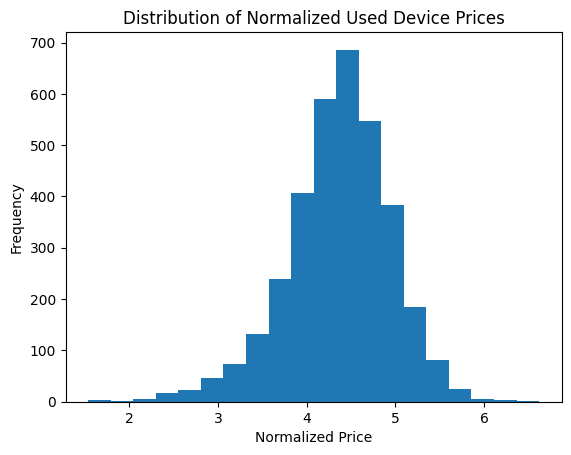

```python
#plotting distribution of a used price

plt.hist(df['normalized_used_price'], bins=20)
plt.xlabel('Normalized Price')
plt.ylabel('Frequency')
plt.title('Distribution of Normalized Used Device Prices')
plt.show()
```

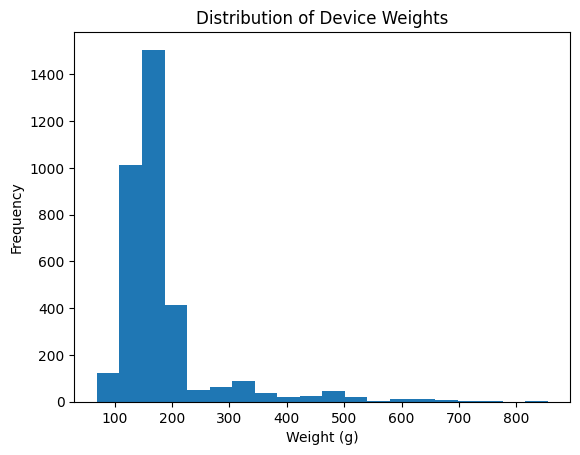

```python
#plot distribution of weight
plt.hist(df['weight'], bins=20)
plt.xlabel('Weight (g)')
plt.ylabel('Frequency')
plt.title('Distribution of Device Weights')
plt.show()
```

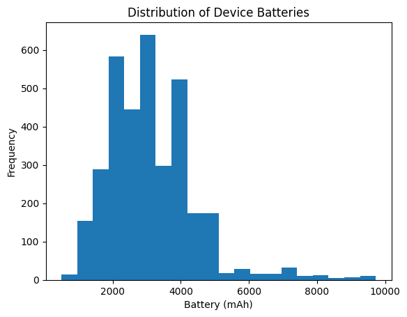

```python
#plot distribution of battery
plt.hist(df['battery'], bins=20)
plt.xlabel('Battery (mAh)')
plt.ylabel('Frequency')
plt.title('Distribution of Device Batteries')
plt.show()
```

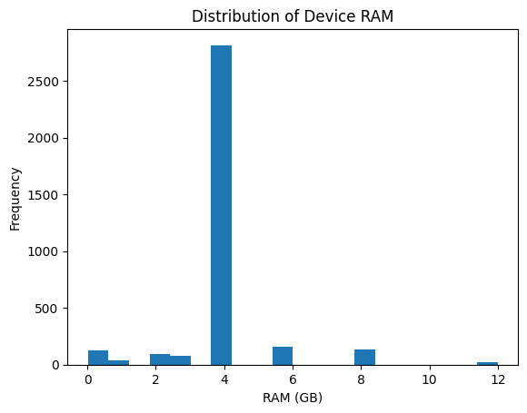

```python
#plot distribution of RAM
plt.hist(df['ram'], bins=20)
plt.xlabel('RAM (GB)')
plt.ylabel('Frequency')
plt.title('Distribution of Device RAM')
plt.show()
```

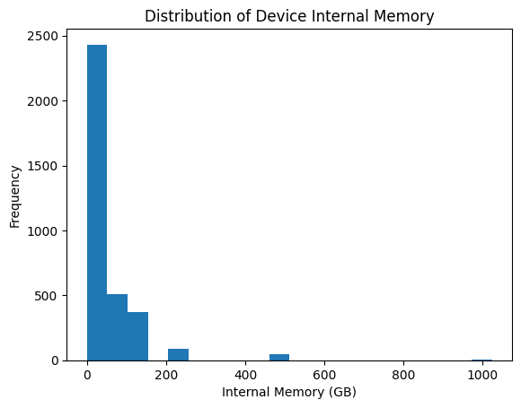

```python
#distribution of memory
plt.hist(df['int_memory'], bins=20)
plt.xlabel('Internal Memory (GB)')
plt.ylabel('Frequency')
plt.title('Distribution of Device Internal Memory')
plt.show()
```

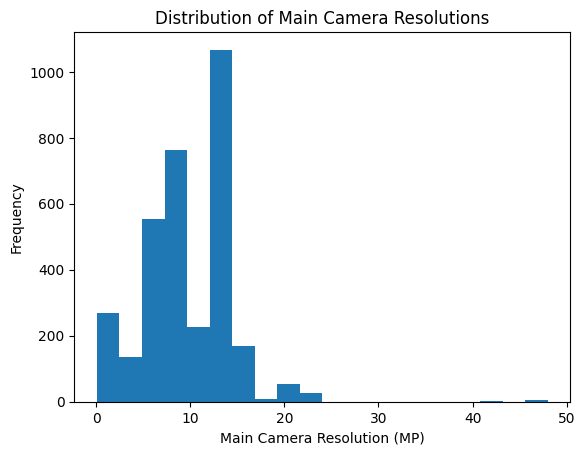

```python
#distribution of main_camera_mp
plt.hist(df['main_camera_mp'], bins=20)
plt.xlabel('Main Camera Resolution (MP)')
plt.ylabel('Frequency')
plt.title('Distribution of Main Camera Resolutions')
plt.show()
```

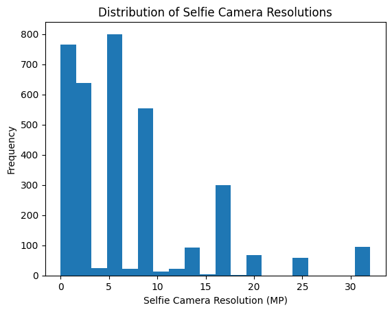

```python
#distribution of selfie_camera_mp
plt.hist(df['selfie_camera_mp'], bins=20)
plt.xlabel('Selfie Camera Resolution (MP)')
plt.ylabel('Frequency')
plt.title('Distribution of Selfie Camera Resolutions')
plt.show()
```

```python
#percentage of used android phones
target_value = 'Android'
count = df['os'].value_counts()[target_value]
total_count = len(df)
percentage = (count / total_count) * 100
print(f"Percentage of used Android devices: {percentage:.2f}%")
```

```
Percentage of used Android devices: 93.05%
```

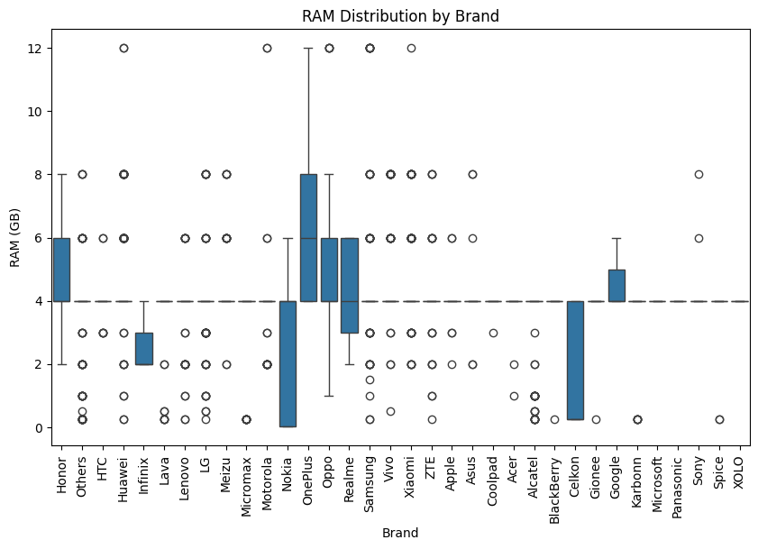

```python
#Checking RAM amount per brand
plt.figure(figsize=(10, 6))
sns.boxplot(x='brand_name', y='ram', data=df)
plt.xlabel('Brand')
plt.ylabel('RAM (GB)')
plt.title('RAM Distribution by Brand')
plt.xticks(rotation=90)
plt.show()
```

```python
#seeing how phone weight varies among phones with at least 4500 mah
filtered_df = df[df['battery'] >= 4500]

#Analyzing weight variation
print("Weight Variation for Phones with at least 4500 mAh Battery:")
print(filtered_df[['weight', 'battery','brand_name']])
```

```
Weight Variation for Phones with at least 4500 mAh Battery:
      weight  battery brand_name
3      480.0   7250.0      Honor
4      185.0   5000.0      Honor
11     185.0   5000.0      Honor
19     173.0   5100.0      Honor
20     173.0   5100.0      Honor
21     453.6   5680.0     Others
31     310.0   5100.0     Huawei
33     450.0   7250.0     Huawei
36     460.0   7250.0     Huawei
40     460.0   7250.0     Huawei
44     198.0   4500.0     Huawei
49     498.0   7500.0     Huawei
50     340.0   6100.0     Huawei
```

[output cut: 393 more lines]

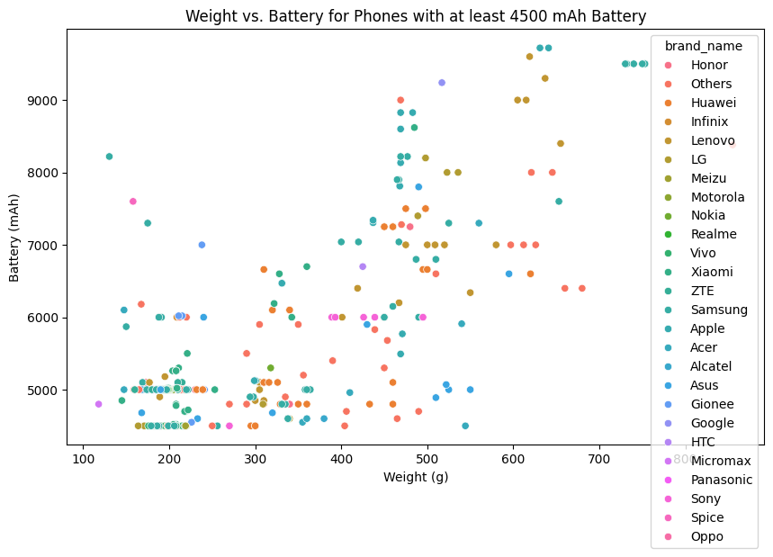

```python
#plot visual of phone battery and weight quick analysis
plt.figure(figsize=(10, 6))
sns.scatterplot(x='weight', y='battery', hue='brand_name', data=filtered_df);
plt.xlabel('Weight (g)')
plt.ylabel('Battery (mAh)')
plt.title('Weight vs. Battery for Phones with at least 4500 mAh Battery')
plt.show()
```

```python
#Phone screen size by Brand
filtered_screen_size_df = df[df['screen_size'] > 6]
brand_screen_size_counts = filtered_screen_size_df.groupby('brand_name').size().reset_index(name='count')
print(brand_screen_size_counts)
```

```
    brand_name  count
0         Acer     51
1      Alcatel    115
2        Apple     39
3         Asus    122
4   BlackBerry     21
5       Celkon     25
6      Coolpad     22
7       Gionee     56
8       Google     15
9          HTC    110
10       Honor    116
11      Huawei    251
12     Infinix     10
13     Karbonn     29
```

[output cut: 20 more lines]

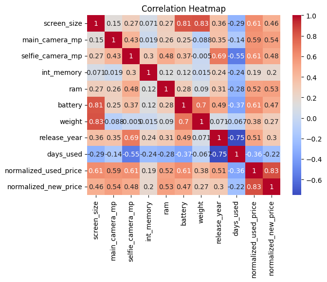

```python
#seeing what fields are correlated
correlation_matrix = df.corr()

sns.heatmap(correlation_matrix, annot=True, cmap='coolwarm')
plt.title('Correlation Heatmap')
plt.show()
```

## Data Preprocessing

- Missing value treatment
- Feature engineering (if needed)
- Outlier detection and treatment (if needed)
- Preparing data for modeling
- Any other preprocessing steps (if needed)

```python
#Because of presents of outliers in certain numeric fields of interest that have missing values and the skewness of these fields I'm imputing the missing values with the median
num_cols = ['main_camera_mp', 'selfie_camera_mp', 'int_memory', 'ram', 'battery', 'weight']
for col in num_cols:
    df[col].fillna(df[col].median(), inplace=True)
```

```python
#Engineering a new feature (phone age)
df['phone_age'] = 2023 - df['release_year']
```

```python
#one-hot-encoding of brand column
df = pd.get_dummies(df, columns=['brand_name'])

#one-hot-encoding os
df = pd.get_dummies(df, columns=['os'])

#one-hot_encoding gigs
df = pd.get_dummies(df, columns=['4g', '5g'])
```

## EDA

- It is a good idea to explore the data once again after manipulating it.

```python
df.head()
```

|  | screen_size | main_camera_mp | selfie_camera_mp | int_memory | ram | battery | weight | release_year | days_used | normalized_used_price | normalized_new_price | phone_age | brand_name_Acer | brand_name_Alcatel | brand_name_Apple | brand_name_Asus | brand_name_BlackBerry | brand_name_Celkon | brand_name_Coolpad | brand_name_Gionee | brand_name_Google | brand_name_HTC | brand_name_Honor | brand_name_Huawei | brand_name_Infinix | brand_name_Karbonn | brand_name_LG | brand_name_Lava | brand_name_Lenovo | … |
| --- | --- | --- | --- | --- | --- | --- | --- | --- | --- | --- | --- | --- | --- | --- | --- | --- | --- | --- | --- | --- | --- | --- | --- | --- | --- | --- | --- | --- | --- | --- |
| 0 | 14.50 | 13.0 | 5.0 | 64.0 | 3.0 | 3020.0 | 146.0 | 2020 | 127 | 4.307572 | 4.715100 | 3 | 0 | 0 | 0 | 0 | 0 | 0 | 0 | 0 | 0 | 0 | 1 | 0 | 0 | 0 | 0 | 0 | 0 | … |
| 1 | 17.30 | 13.0 | 16.0 | 128.0 | 8.0 | 4300.0 | 213.0 | 2020 | 325 | 5.162097 | 5.519018 | 3 | 0 | 0 | 0 | 0 | 0 | 0 | 0 | 0 | 0 | 0 | 1 | 0 | 0 | 0 | 0 | 0 | 0 | … |
| 2 | 16.69 | 13.0 | 8.0 | 128.0 | 8.0 | 4200.0 | 213.0 | 2020 | 162 | 5.111084 | 5.884631 | 3 | 0 | 0 | 0 | 0 | 0 | 0 | 0 | 0 | 0 | 0 | 1 | 0 | 0 | 0 | 0 | 0 | 0 | … |
| 3 | 25.50 | 13.0 | 8.0 | 64.0 | 6.0 | 7250.0 | 480.0 | 2020 | 345 | 5.135387 | 5.630961 | 3 | 0 | 0 | 0 | 0 | 0 | 0 | 0 | 0 | 0 | 0 | 1 | 0 | 0 | 0 | 0 | 0 | 0 | … |
| 4 | 15.32 | 13.0 | 8.0 | 64.0 | 3.0 | 5000.0 | 185.0 | 2020 | 293 | 4.389995 | 4.947837 | 3 | 0 | 0 | 0 | 0 | 0 | 0 | 0 | 0 | 0 | 0 | 1 | 0 | 0 | 0 | 0 | 0 | 0 | … |

```python
#updated null count
df.isnull().sum()
```

|  | 0 |
| --- | --- |
| screen_size | 0 |
| main_camera_mp | 0 |
| selfie_camera_mp | 0 |
| int_memory | 0 |
| ram | 0 |
| battery | 0 |
| weight | 0 |
| release_year | 0 |
| days_used | 0 |
| normalized_used_price | 0 |
| normalized_new_price | 0 |
| phone_age | 0 |
| brand_name_Acer | 0 |
| brand_name_Alcatel | 0 |
| brand_name_Apple | 0 |
| brand_name_Asus | 0 |
| brand_name_BlackBerry | 0 |
| brand_name_Celkon | 0 |
| brand_name_Coolpad | 0 |
| brand_name_Gionee | 0 |
| brand_name_Google | 0 |
| brand_name_HTC | 0 |
| brand_name_Honor | 0 |
| brand_name_Huawei | 0 |
| brand_name_Infinix | 0 |
| brand_name_Karbonn | 0 |
| brand_name_LG | 0 |
| brand_name_Lava | 0 |
| brand_name_Lenovo | 0 |
| brand_name_Meizu | 0 |
| brand_name_Micromax | 0 |
| brand_name_Microsoft | 0 |
| brand_name_Motorola | 0 |
| brand_name_Nokia | 0 |
| brand_name_OnePlus | 0 |
| brand_name_Oppo | 0 |
| brand_name_Others | 0 |
| brand_name_Panasonic | 0 |
| brand_name_Realme | 0 |
| brand_name_Samsung | 0 |
| brand_name_Sony | 0 |
| brand_name_Spice | 0 |
| brand_name_Vivo | 0 |
| brand_name_XOLO | 0 |
| brand_name_Xiaomi | 0 |
| brand_name_ZTE | 0 |
| os_Android | 0 |
| os_Others | 0 |
| os_Windows | 0 |
| os_iOS | 0 |
| 4g_no | 0 |
| 4g_yes | 0 |
| 5g_no | 0 |
| 5g_yes | 0 |

**dtype:** int64

## Model Building - Linear Regression

```python
#Splitting data
from sklearn.model_selection import train_test_split

X = df.drop(columns=['normalized_used_price'])
y = df['normalized_used_price']

X_train, X_test, y_train, y_test = train_test_split(X, y, test_size=0.2, random_state=42)
```

```python
#Building and Training Model
from sklearn.linear_model import LinearRegression

model = LinearRegression()
model.fit(X_train, y_train)
```

```
LinearRegression()
```

## Model Performance Check

```python
#Predicting and Evaluting model
from sklearn.metrics import mean_squared_error, r2_score

y_pred = model.predict(X_test)

mse = mean_squared_error(y_test, y_pred)
r2 = r2_score(y_test, y_pred)
rmse = mean_squared_error(y_test, y_pred, squared=False)

print("Mean Squared Error:", mse)
print("R-squared:", r2)
print("Root Mean Squared Error:", rmse)
```

```
Mean Squared Error: 0.05330904376614514
R-squared: 0.8357287938412622
Root Mean Squared Error: 0.2308875132313247
```

```python
#Identifying influential factors
coefficients = model.coef_
feature_names = X.columns

coefficients_df = pd.DataFrame({'Feature': feature_names, 'Coefficient': coefficients})
coefficients_df = coefficients_df.sort_values(by='Coefficient', ascending=False)

print("Influential Factors:")
print(coefficients_df)
```

```
Influential Factors:
                  Feature  Coefficient
9    normalized_new_price     0.424590
23     brand_name_Infinix     0.128474
37      brand_name_Realme     0.097292
30   brand_name_Microsoft     0.084463
43      brand_name_Xiaomi     0.078985
32       brand_name_Nokia     0.068217
33     brand_name_OnePlus     0.064498
45             os_Android     0.046908
15  brand_name_BlackBerry     0.043567
14        brand_name_Asus     0.032564
47             os_Windows     0.030443
17     brand_name_Coolpad     0.028535
0             screen_size     0.028125
```

[output cut: 40 more lines]

```python
#OLS
import statsmodels.api as sm

X_train_with_constant = sm.add_constant(X_train)
model_with_constant = sm.OLS(y_train, X_train_with_constant)
results = model_with_constant.fit()
results.summary()
```

OLS Regression Results

| Dep. Variable: | normalized_used_price | R-squared: | 0.847 |
| --- | --- | --- | --- |
| Model: | OLS | Adj. R-squared: | 0.844 |
| Method: | Least Squares | F-statistic: | 313.1 |
| Date: | Mon, 28 Jul 2025 | Prob (F-statistic): | 0.00 |
| Time: | 11:17:04 | Log-Likelihood: | 115.07 |
| No. Observations: | 2763 | AIC: | -132.1 |
| Df Residuals: | 2714 | BIC: | 158.1 |
| Df Model: | 48 |  |  |
| Covariance Type: | nonrobust |  |  |

|  | coef | std err | t | P>\|t\| | [0.025 | 0.975] |
| --- | --- | --- | --- | --- | --- | --- |
| const | -1.246e-05 | 2.1e-06 | -5.920 | 0.000 | -1.66e-05 | -8.33e-06 |
| screen_size | 0.0281 | 0.003 | 8.508 | 0.000 | 0.022 | 0.035 |
| main_camera_mp | 0.0213 | 0.001 | 15.347 | 0.000 | 0.019 | 0.024 |
| selfie_camera_mp | 0.0127 | 0.001 | 11.580 | 0.000 | 0.011 | 0.015 |
| int_memory | 9.163e-05 | 5.95e-05 | 1.541 | 0.123 | -2.5e-05 | 0.000 |
| ram | 0.0257 | 0.005 | 5.176 | 0.000 | 0.016 | 0.035 |
| battery | -1.756e-05 | 7.05e-06 | -2.490 | 0.013 | -3.14e-05 | -3.73e-06 |
| weight | 0.0008 | 0.000 | 6.645 | 0.000 | 0.001 | 0.001 |
| release_year | 0.0007 | 3.28e-05 | 20.790 | 0.000 | 0.001 | 0.001 |
| days_used | 2.313e-05 | 2.87e-05 | 0.805 | 0.421 | -3.32e-05 | 7.95e-05 |
| normalized_new_price | 0.4246 | 0.012 | 36.808 | 0.000 | 0.402 | 0.447 |
| phone_age | -0.0259 | 0.004 | -6.070 | 0.000 | -0.034 | -0.018 |
| brand_name_Acer | 0.0206 | 0.039 | 0.533 | 0.594 | -0.055 | 0.096 |
| brand_name_Alcatel | -0.0496 | 0.025 | -1.947 | 0.052 | -0.099 | 0.000 |
| brand_name_Apple | 0.0131 | 0.138 | 0.095 | 0.925 | -0.257 | 0.283 |
| brand_name_Asus | 0.0326 | 0.025 | 1.328 | 0.184 | -0.016 | 0.081 |
| brand_name_BlackBerry | 0.0436 | 0.055 | 0.786 | 0.432 | -0.065 | 0.152 |
| brand_name_Celkon | -0.1658 | 0.049 | -3.418 | 0.001 | -0.261 | -0.071 |
| brand_name_Coolpad | 0.0285 | 0.052 | 0.551 | 0.581 | -0.073 | 0.130 |
| brand_name_Gionee | -0.0121 | 0.038 | -0.318 | 0.751 | -0.087 | 0.063 |
| brand_name_Google | -0.0724 | 0.067 | -1.082 | 0.279 | -0.204 | 0.059 |
| brand_name_HTC | -0.0030 | 0.026 | -0.117 | 0.907 | -0.054 | 0.048 |
| brand_name_Honor | -0.0038 | 0.025 | -0.154 | 0.878 | -0.053 | 0.045 |
| brand_name_Huawei | -0.0277 | 0.018 | -1.526 | 0.127 | -0.063 | 0.008 |
| brand_name_Infinix | 0.1285 | 0.087 | 1.469 | 0.142 | -0.043 | 0.300 |
| brand_name_Karbonn | -0.0268 | 0.048 | -0.556 | 0.578 | -0.121 | 0.068 |
| brand_name_LG | -0.0350 | 0.020 | -1.727 | 0.084 | -0.075 | 0.005 |
| brand_name_Lava | -0.0048 | 0.045 | -0.107 | 0.914 | -0.092 | 0.083 |
| brand_name_Lenovo | 0.0123 | 0.021 | 0.576 | 0.564 | -0.029 | 0.054 |
| brand_name_Meizu | -0.0133 | 0.035 | -0.379 | 0.704 | -0.082 | 0.056 |
| brand_name_Micromax | -0.0355 | 0.025 | -1.404 | 0.161 | -0.085 | 0.014 |
| brand_name_Microsoft | 0.0845 | 0.066 | 1.286 | 0.199 | -0.044 | 0.213 |
| brand_name_Motorola | -0.0269 | 0.027 | -1.014 | 0.311 | -0.079 | 0.025 |
| brand_name_Nokia | 0.0682 | 0.029 | 2.359 | 0.018 | 0.012 | 0.125 |
| brand_name_OnePlus | 0.0645 | 0.055 | 1.164 | 0.245 | -0.044 | 0.173 |
| brand_name_Oppo | 0.0053 | 0.024 | 0.218 | 0.827 | -0.042 | 0.053 |
| brand_name_Others | -0.0282 | 0.014 | -1.991 | 0.047 | -0.056 | -0.000 |
| brand_name_Panasonic | 0.0051 | 0.041 | 0.124 | 0.901 | -0.076 | 0.086 |
| brand_name_Realme | 0.0973 | 0.043 | 2.241 | 0.025 | 0.012 | 0.182 |
| brand_name_Samsung | -0.0317 | 0.016 | -1.952 | 0.051 | -0.064 | 0.000 |
| brand_name_Sony | -0.0533 | 0.029 | -1.862 | 0.063 | -0.109 | 0.003 |
| brand_name_Spice | -0.0165 | 0.050 | -0.327 | 0.744 | -0.115 | 0.082 |
| brand_name_Vivo | -0.0291 | 0.026 | -1.131 | 0.258 | -0.080 | 0.021 |
| brand_name_XOLO | -0.0312 | 0.037 | -0.847 | 0.397 | -0.104 | 0.041 |
| brand_name_Xiaomi | 0.0790 | 0.025 | 3.217 | 0.001 | 0.031 | 0.127 |
| brand_name_ZTE | -0.0162 | 0.023 | -0.706 | 0.480 | -0.061 | 0.029 |
| os_Android | 0.0469 | 0.041 | 1.141 | 0.254 | -0.034 | 0.127 |
| os_Others | -0.0411 | 0.040 | -1.037 | 0.300 | -0.119 | 0.037 |
| os_Windows | 0.0304 | 0.049 | 0.624 | 0.533 | -0.065 | 0.126 |
| os_iOS | -0.0363 | 0.109 | -0.333 | 0.739 | -0.250 | 0.178 |
| 4g_no | -0.0188 | 0.008 | -2.497 | 0.013 | -0.033 | -0.004 |
| 4g_yes | 0.0187 | 0.008 | 2.495 | 0.013 | 0.004 | 0.033 |
| 5g_no | 0.0205 | 0.015 | 1.363 | 0.173 | -0.009 | 0.050 |
| 5g_yes | -0.0205 | 0.015 | -1.364 | 0.173 | -0.050 | 0.009 |

| Omnibus: | 262.571 | Durbin-Watson: | 1.975 |
| --- | --- | --- | --- |
| Prob(Omnibus): | 0.000 | Jarque-Bera (JB): | 696.882 |
| Skew: | -0.531 | Prob(JB): | 4.72e-152 |
| Kurtosis: | 5.219 | Cond. No. | 2.85e+18 |

Notes:  
[1] Standard Errors assume that the covariance matrix of the errors is correctly specified.  
[2] The smallest eigenvalue is 5.29e-27. This might indicate that there are  
strong multicollinearity problems or that the design matrix is singular.

## Checking Linear Regression Assumptions

- In order to make statistical inferences from a linear regression model, it is important to ensure that the assumptions of linear regression are satisfied.

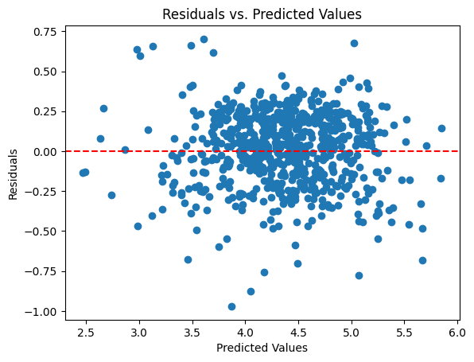

```python
#calculating residuals
residuals = y_test - y_pred

#Linearity & Homoscedasticity Test
plt.scatter(y_pred, residuals)
plt.axhline(y=0, color='r', linestyle='--')
plt.xlabel('Predicted Values')
plt.ylabel('Residuals')
plt.title('Residuals vs. Predicted Values')
plt.show()
```

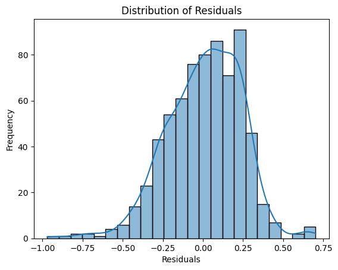

```python
#Normality Test
sns.histplot(residuals, kde=True)
plt.xlabel('Residuals')
plt.ylabel('Frequency')
plt.title('Distribution of Residuals')
plt.show()
```

```python
#Multicollinearity test
from statsmodels.stats.outliers_influence import variance_inflation_factor

vif_data = pd.DataFrame()
vif_data["Feature"] = X.columns
vif_data["VIF"] = [variance_inflation_factor(X.values, i) for i in range(X.shape[1])]
print(vif_data)
```

```
                  Feature       VIF
0             screen_size  7.234351
1          main_camera_mp  2.140280
2        selfie_camera_mp  2.854270
3              int_memory  1.296283
4                     ram  2.253951
5                 battery  4.187970
6                  weight  5.774759
7            release_year       inf
8               days_used  2.584249
9    normalized_new_price  3.109070
10              phone_age       inf
11        brand_name_Acer       inf
12     brand_name_Alcatel       inf
13       brand_name_Apple       inf
```

[output cut: 39 more lines]

```python
#Independence test
from statsmodels.stats.stattools import durbin_watson

dw_statistic = durbin_watson(residuals)
print("Durbin-Watson Statistic:", dw_statistic)
```

```
Durbin-Watson Statistic: 1.8708746084098844
```

## Final Model

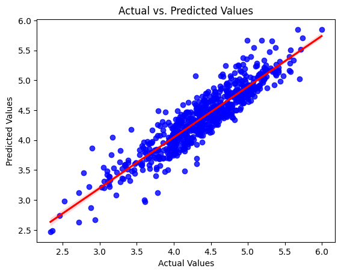

```python
#plotting Model with regression line
sns.regplot(x=y_test, y=y_pred, scatter_kws={'color': 'blue'}, line_kws={'color': 'red'})
plt.xlabel('Actual Values')
plt.ylabel('Predicted Values')
plt.title('Actual vs. Predicted Values')
plt.show()
```

## Actionable Insights and Recommendations

### These brands can allow you to offer premium prices as they tend to increase price based on model.

### For these brands, it may make sense to also bundle them with another service or product to help transaction value.

```python
#Converting notebook to html
from google.colab import files
! jupyter nbconvert --to html '/content/drive/MyDrive/Recell_LinearR_Data/SLF_Project_LearnerNotebook_FullCodeAWatson.ipynb'
files.download('/content/drive/MyDrive/Recell_LinearR_Data/SLF_Project_LearnerNotebook_FullCodeAWatson.html')
```

```
[NbConvertApp] Converting notebook /content/drive/MyDrive/Recell_LinearR_Data/SLF_Project_LearnerNotebook_FullCodeAWatson.ipynb to html
[NbConvertApp] WARNING | Alternative text is missing on 13 image(s).
[NbConvertApp] Writing 1102603 bytes to /content/drive/MyDrive/Recell_LinearR_Data/SLF_Project_LearnerNotebook_FullCodeAWatson.html
```